# Pentathlon III: Next Product to Buy Modeling

- Team-lead gitlab id: rsm-n1gong
- Team-lead gitlab username: Nawen Gong
- Group number: 12
- Group name: Team 12
- Team member names: Nawen Gong, Zichen Huang, Xinyue Tao, Zheng Shan

## Setup

Please complete this Rmarkdown document by answering the questions in `pentathlon-nptb.pdf` on Dropbox (week8/readings/). The code block below will load the data you need. Please DO NOT change the code used to load the data. Create an HTML file with all your results and comments and push both the Rmarkdown and HTML file to GitLab when you are done. As always, all results MUST be reproducible (i.e., the TA and I must be able to recreate the HTML from the R-markdown file without changes or errors).

Good luck!

## Question answers

Separate datasets into train/val/reps

#### parameters to use

```r
## list response (rvar), explanatory (evar)  and interaction (int) variables
rvar <- "buyer"

evar <- c("message","age", "gender", "income", "education", "children", "freq_endurance",
          "freq_strength", "freq_water", "freq_team", "freq_backcountry", "freq_winter",
          "freq_racquet")

int <- c("message:age", "message:gender", "message:income", "message:education",
         "message:children", "message:freq_endurance", "message:freq_strength",
         "message:freq_water", "message:freq_team", "message:freq_backcountry",
         "message:freq_winter", "message:freq_racquet")

lev <- "yes"
```

#### Create dataframe for model evaluation

```
# A tibble: 6 x 2
  buyer training
  <fct>    <int>
1 no          NA
2 no          NA
3 no           1
4 no          NA
5 no          NA
6 yes          1
```

## Model Evaluation and Selection

## Logistic

```
Logistic regression (GLM)
Data                 : pentathlon_nptb
Filter               : training == 1
Response variable    : buyer
Level                : yes in buyer
Explanatory variables: message, age, gender, income, education, children, freq_endurance, freq_strength, freq_water, freq_team, freq_backcountry, freq_winter, freq_racquet
Null hyp.: there is no effect of x on buyer
Alt. hyp.: there is an effect of x on buyer

                                         OR coefficient std.error z.value p.value
 (Intercept)                                     -4.613     0.144 -31.975  < .001 ***
 message|strength                     0.749      -0.289     0.209  -1.386   0.166
 message|water                        0.867      -0.143     0.206  -0.695   0.487
 message|team                         0.678      -0.388     0.208  -1.871   0.061 .
 message|backcountry                  0.816      -0.203     0.206  -0.987   0.323
 message|winter                       0.845      -0.169     0.208  -0.811   0.418
 message|racquet                      0.957      -0.044     0.204  -0.217   0.828
 age|30 to 44                         2.078       0.731     0.086   8.468  < .001 ***
 age|45 to 59                         1.974       0.680     0.089   7.628  < .001 ***
 age|>= 60                            1.138       0.130     0.106   1.218   0.223
 gender|F                             0.827      -0.190     0.058  -3.286   0.001 **
 income                               1.000       0.000     0.000  10.300  < .001 ***
 education                            1.037       0.037     0.003  12.422  < .001 ***
 children                             1.605       0.473     0.068   6.920  < .001 ***
 freq_endurance                       1.115       0.108     0.019   5.690  < .001 ***
 freq_strength                        1.119       0.113     0.012   9.778  < .001 ***
 freq_water                           1.235       0.211     0.055   3.802  < .001 ***
 freq_team                            1.063       0.061     0.015   4.021  < .001 ***
 freq_backcountry                     1.183       0.168     0.031   5.438  < .001 ***
 freq_winter                          1.507       0.410     0.114   3.595  < .001 ***
 freq_racquet                         1.134       0.126     0.021   5.874  < .001 ***
 message|strength:age|30 to 44        1.343       0.295     0.123   2.387   0.017 *
 message|water:age|30 to 44           1.076       0.073     0.123   0.596   0.552
 message|team:age|30 to 44            1.050       0.048     0.123   0.392   0.695
 message|backcountry:age|30 to 44     0.990      -0.010     0.124  -0.081   0.935
 message|winter:age|30 to 44          1.113       0.107     0.125   0.861   0.389
 message|racquet:age|30 to 44         0.988      -0.012     0.123  -0.095   0.924
 message|strength:age|45 to 59        0.956      -0.045     0.127  -0.350   0.726
 message|water:age|45 to 59           1.075       0.073     0.126   0.575   0.565
 message|team:age|45 to 59            1.155       0.144     0.127   1.135   0.256
```

[output cut: 67 more lines]

```
 message|winter:freq_winter           1.043       0.042     0.156   0.268   0.789
 message|racquet:freq_winter          0.934      -0.068     0.157  -0.436   0.663
 message|strength:freq_racquet        1.007       0.007     0.031   0.222   0.824
 message|water:freq_racquet           1.000      -0.000     0.030  -0.013   0.990
 message|team:freq_racquet            0.993      -0.007     0.030  -0.242   0.809
 message|backcountry:freq_racquet     1.002       0.002     0.030   0.079   0.937
 message|winter:freq_racquet          1.031       0.030     0.030   1.014   0.310
 message|racquet:freq_racquet         1.019       0.019     0.030   0.634   0.526

Signif. codes:  0 '***' 0.001 '**' 0.01 '*' 0.05 '.' 0.1 ' ' 1

Pseudo R-squared: 0.373
Log-likelihood: -30434.233, AIC: 61078.465, BIC: 62039.872
Chi-squared: 36172.14 df(104), p.value < .001
Nr obs: 70,000
```

```
# A tibble: 6 x 3
  buyer training logit
  <fct>    <int> <dbl>
1 no          NA 0.116
2 no          NA 0.321
3 no           1 0.351
4 no          NA 0.203
5 no          NA 0.235
6 yes          1 0.571
```

## Ctree(Radiant classification tree model)

#### Train (default parameters)

```
Classification tree
Data                 : train
Response variable    : buyer
Level                : yes in buyer
Explanatory variables: message, age, gender, income, education, children, freq_endurance, freq_strength, freq_water, freq_team, freq_backcountry, freq_winter, freq_racquet
Complexity parameter : 0.001
Minimum observations : 2
Cost:Margin          : 0.6 : 1
Nr obs               : 70,000
```

#### tune the model using cross validation

**Given the provided tuning grid, the pruning complexity parameter should be set to 0 or the number of nodes set to 16**

```
  auc (mean)         std       min       max    cp pcp
1  0.8416078 0.008216653 0.8355105 0.8556028 0.001   0
```

#### Now trian with the best parameter and test on the whole datasets

```
Classification tree
Data                 : train
Response variable    : buyer
Level                : yes in buyer
Explanatory variables: message, age, gender, income, education, children, freq_endurance, freq_strength, freq_water, freq_team, freq_backcountry, freq_winter, freq_racquet
Complexity parameter : 0.001
Minimum observations : 2
Maximum nr. nodes    : 16 out of 16
Cost:Margin          : 0.6 : 1
Nr obs               : 70,000
```

```
# A tibble: 6 x 4
  buyer training logit ctree
  <fct>    <int> <dbl> <dbl>
1 no          NA 0.116 0.172
2 no          NA 0.321 0.319
3 no           1 0.351 0.172
4 no          NA 0.203 0.172
5 no          NA 0.235 0.172
6 yes          1 0.571 0.900
```

## Nerual Network

#### using radiant.model::nn

```r
res_nn <- read_rds("res_nn.rds")
```

res_nn <- nn( train, rvar = rvar, evar = evar, lev = lev, size = 5, decay = 0.5, data_filter = “training == 1”, seed = 1234 ) summary(res_nn) saveRDS(res_nn, “res_nn.rds”)

```
  AUC (mean)         std       min       max decay size
1  0.8907561 0.004471800 0.8853740 0.8977920   0.3    6
2  0.8906415 0.002660746 0.8881742 0.8946995   0.2    8
3  0.8906055 0.001233447 0.8898209 0.8927893   0.4    6
4  0.8905339 0.002533092 0.8865118 0.8930606   0.2    4
5  0.8905062 0.002203212 0.8872720 0.8926768   0.2    6
6  0.8905030 0.002884742 0.8883846 0.8950932   0.1    4
```

#### based on cross validation the best nn has 6 nodes in the hidden layer and decay set to 0.3

```
Neural Network
Activation function  : Logistic (classification)
Data                 : pentathlon_nptb
Filter               : training == 1
Response variable    : buyer
Level                : yes in buyer
Explanatory variables: message, age, gender, income, education, children, freq_endurance, freq_strength, freq_water, freq_team, freq_backcountry, freq_winter, freq_racquet
Network size         : 6
Parameter decay      : 0.3
Seed                 : 1234
Network              : 20-6-1 with 133 weights
Nr obs               : 70,000
Weights              :
    b->h1  i1->h1  i2->h1  i3->h1  i4->h1  i5->h1  i6->h1  i7->h1  i8->h1  i9->h1 i10->h1 i11->h1
     3.66    0.22    0.40    0.38    0.45    0.10    0.47    2.81    2.53    0.27   -1.54    3.71
  i12->h1 i13->h1 i14->h1 i15->h1 i16->h1 i17->h1 i18->h1 i19->h1 i20->h1
     3.55    1.16   -0.10    0.41   -0.70   -0.10    0.27   -0.73   -0.15
    b->h2  i1->h2  i2->h2  i3->h2  i4->h2  i5->h2  i6->h2  i7->h2  i8->h2  i9->h2 i10->h2 i11->h2
     1.00    0.39    0.30    0.09    0.47    0.36    0.42    2.19    2.04    0.42   -0.87    3.27
  i12->h2 i13->h2 i14->h2 i15->h2 i16->h2 i17->h2 i18->h2 i19->h2 i20->h2
     3.52    1.13   -0.45   -0.43   -0.60   -0.31    0.27   -0.14    0.41
    b->h3  i1->h3  i2->h3  i3->h3  i4->h3  i5->h3  i6->h3  i7->h3  i8->h3  i9->h3 i10->h3 i11->h3
     0.12   -1.33   -0.02    1.46    0.45   -0.51    0.34   -2.79    0.09    0.18   -0.06   -0.98
  i12->h3 i13->h3 i14->h3 i15->h3 i16->h3 i17->h3 i18->h3 i19->h3 i20->h3
    -0.90   -0.56    0.47   -0.03    0.28    0.47    0.60   -0.15   -0.64
    b->h4  i1->h4  i2->h4  i3->h4  i4->h4  i5->h4  i6->h4  i7->h4  i8->h4  i9->h4 i10->h4 i11->h4
     1.16    0.00    0.14    0.16    0.60    0.34    0.31   -0.25    0.50    0.37    0.17    1.37
  i12->h4 i13->h4 i14->h4 i15->h4 i16->h4 i17->h4 i18->h4 i19->h4 i20->h4
     0.81    0.13   -0.58   -1.37   -1.69   -0.50   -0.24   -0.27    0.77
    b->h5  i1->h5  i2->h5  i3->h5  i4->h5  i5->h5  i6->h5  i7->h5  i8->h5  i9->h5 i10->h5 i11->h5
    -3.78    0.27    0.28    0.53    0.53    0.57    0.42    0.13    0.71    0.44    0.04    0.36
  i12->h5 i13->h5 i14->h5 i15->h5 i16->h5 i17->h5 i18->h5 i19->h5 i20->h5
     0.16   -0.11   -0.79   -3.52   -1.32   -0.40   -0.67   -0.44   -0.19
    b->h6  i1->h6  i2->h6  i3->h6  i4->h6  i5->h6  i6->h6  i7->h6  i8->h6  i9->h6 i10->h6 i11->h6
    -1.03    0.10   -0.10   -0.37   -0.20   -0.06   -0.26    0.53    0.33   -0.12   -0.11    1.29
  i12->h6 i13->h6 i14->h6 i15->h6 i16->h6 i17->h6 i18->h6 i19->h6 i20->h6
     0.78    0.24    0.12    0.02   -0.44   -0.03   -0.04    0.08    0.56
   b->o h1->o h2->o h3->o h4->o h5->o h6->o
   0.75 -5.19  5.68  1.26 -2.43 -3.21  4.81
```

## GBM

Preprocessing data

```r
dat_train <- train[, -c(17:25, 1, 3)]
dat_train$buyer <- ifelse(dat_train$buyer == 'yes', 1, 0)
dat_tree <- model.matrix(~.+0,data =dat_train[,-1])
dat_tree <- data.frame(buyer = dat_train[,1], dat_tree)

## Test set
dat_val <- val[, -c(17:25, 1, 3)]
dat_val$buyer <- ifelse(dat_val$buyer == 'yes', 1, 0)
dat_tree_val <- model.matrix(~.+0,data =dat_val[,-1])
dat_tree_val <- data.frame(buyer = dat_val[,1], dat_tree_val)
```

### tune and train the GBM model

```r
gbmGrid <-  expand.grid(interaction.depth = seq(1, 5, 1),
                        n.trees = seq(101, 501, 100),
                        shrinkage = c(0.01, 0.1, 0.5),
                        n.minobsinnode = 10)


fitControl <- trainControl(method = "repeatedcv",
                           number = 5,
                           ## Estimate class probabilities
                           classProbs = TRUE,
                           ## Evaluate performance using
                           ## the following function
                           summaryFunction = twoClassSummary)

set.seed(1234)
```

gbmFit <- train(buyer ~ ., data = dat_train, method = “gbm”, trControl = fitControl, verbose = FALSE, tuneGrid = gbmGrid, ## Specify which metric to optimize metric = “ROC”)

```
[1] 401
```

gbm_tr <- gbm( formula = buyer ~ ., distribution = “bernoulli”, data = dat_train, n.trees = 401, interaction.depth = 5, shrinkage = 0.1, cv.folds = 5, )  
saveRDS(gbm_tr, “gbm_tuned.rds”)

```
# A tibble: 6 x 6
  buyer training logit ctree    NN    gbm
  <fct>    <int> <dbl> <dbl> <dbl>  <dbl>
1 no          NA 0.116 0.172 0.116 0.0734
2 no          NA 0.321 0.319 0.321 0.328
3 no           1 0.351 0.172 0.351 0.378
4 no          NA 0.203 0.172 0.203 0.130
5 no          NA 0.235 0.172 0.235 0.195
6 yes          1 0.571 0.900 0.571 0.641
```

## Evaluate Different Models by Gains

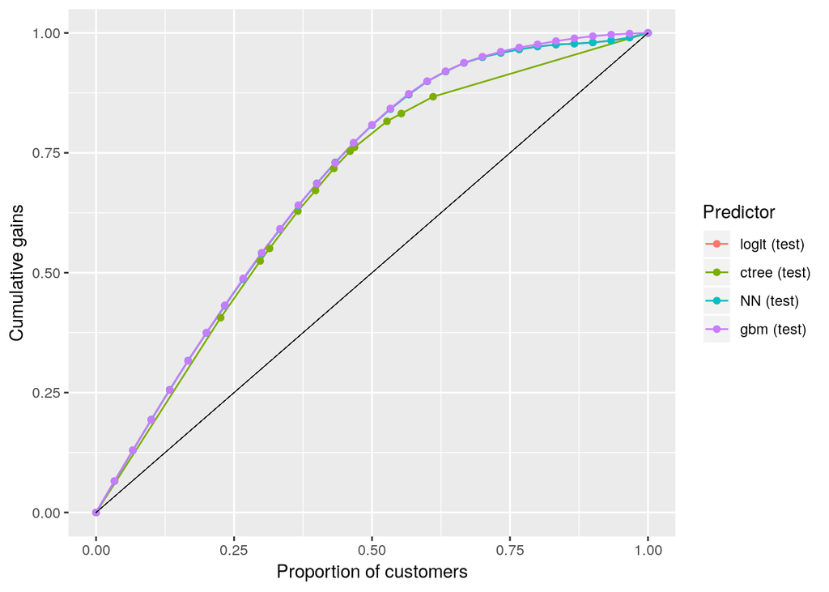

## Evaluate Different Models by Performance

```
Confusion matrix
Data       : eval_dat
Filter     : training == 1
Results for: Test
Predictors : logit, ctree, NN, gbm
Response   : buyer
Level      : yes in buyer
Cost:Margin: 1 : 2

 Type Predictor     TP    FP     TN    FN  total   TPR   TNR precision Fscore
 Test     logit 11,802 2,624 12,376 3,198 30,000 0.787 0.825     0.818  0.802
 Test     ctree 11,300 2,503 12,497 3,700 30,000 0.753 0.833     0.819  0.785
 Test        NN 11,802 2,624 12,376 3,198 30,000 0.787 0.825     0.818  0.802
 Test       gbm 12,235 2,967 12,033 2,765 30,000 0.816 0.802     0.805  0.810

 Type Predictor accuracy kappa profit index  ROME contact   AUC
 Test     logit    0.806 0.612  9,178 0.990 0.636   0.481 0.883
 Test     ctree    0.793 0.586  8,797 0.949 0.637   0.460 0.841
 Test        NN    0.806 0.612  9,178 0.990 0.636   0.481 0.883
 Test       gbm    0.809 0.618  9,268 1.000 0.610   0.507 0.888
```

> Based on the model evalutaion, we decided to use logistics regression as our final model to predict purchase probability. As we can see, GBM model, though slightly better than the rest model, cannot distinguishing itself too much to logit model. When performance is similar, we prefer the simplier model over the sophisticated ones as the simple model is easier to intepretat and gigging out useful insights. Therefore, we’ll conduct the following NPTB analysis using logistics regression model to predict customers’ purchase probability.

### Logistic Model

**We use training data to train the logistic model and predict on the representative datasets**

```
Logistic regression (GLM)
Data                 : train
Response variable    : buyer
Level                : yes in buyer
Explanatory variables: message, age, gender, income, education, children, freq_endurance, freq_strength, freq_water, freq_team, freq_backcountry, freq_winter, freq_racquet
Null hyp.: there is no effect of x on buyer
Alt. hyp.: there is an effect of x on buyer
**Standardized odds-ratios and coefficients shown (2 X SD)**

                                         OR coefficient std.error z.value p.value
 (Intercept)                                     -0.107     0.079  -1.346   0.178
 message|strength                     0.942      -0.060     0.113  -0.526   0.599
 message|water                        0.893      -0.113     0.113  -0.998   0.318
 message|team                         0.828      -0.189     0.113  -1.663   0.096 .
 message|backcountry                  0.797      -0.227     0.114  -2.002   0.045 *
 message|winter                       0.777      -0.252     0.115  -2.197   0.028 *
 message|racquet                      0.868      -0.141     0.113  -1.256   0.209
 age|30 to 44                         2.078       0.731     0.086   8.468  < .001 ***
 age|45 to 59                         1.974       0.680     0.089   7.628  < .001 ***
 age|>= 60                            1.138       0.130     0.106   1.218   0.223
 gender|F                             0.827      -0.190     0.058  -3.286   0.001 **
 income                               3.712       1.312     0.127  10.300  < .001 ***
 education                            4.067       1.403     0.113  12.422  < .001 ***
 children                             1.534       0.428     0.062   6.920  < .001 ***
 freq_endurance                       1.650       0.501     0.088   5.690  < .001 ***
 freq_strength                        2.195       0.786     0.080   9.778  < .001 ***
 freq_water                           1.424       0.354     0.093   3.802  < .001 ***
 freq_team                            1.345       0.296     0.074   4.021  < .001 ***
 freq_backcountry                     1.424       0.353     0.065   5.438  < .001 ***
 freq_winter                          1.314       0.273     0.076   3.595  < .001 ***
 freq_racquet                         1.588       0.462     0.079   5.874  < .001 ***
 message|strength:age|30 to 44        1.343       0.295     0.123   2.387   0.017 *
 message|water:age|30 to 44           1.076       0.073     0.123   0.596   0.552
 message|team:age|30 to 44            1.050       0.048     0.123   0.392   0.695
 message|backcountry:age|30 to 44     0.990      -0.010     0.124  -0.081   0.935
 message|winter:age|30 to 44          1.113       0.107     0.125   0.861   0.389
 message|racquet:age|30 to 44         0.988      -0.012     0.123  -0.095   0.924
 message|strength:age|45 to 59        0.956      -0.045     0.127  -0.350   0.726
 message|water:age|45 to 59           1.075       0.073     0.126   0.575   0.565
 message|team:age|45 to 59            1.155       0.144     0.127   1.135   0.256
```

[output cut: 67 more lines]

```
 message|winter:freq_winter           1.028       0.028     0.104   0.268   0.789
 message|racquet:freq_winter          0.955      -0.046     0.104  -0.436   0.663
 message|strength:freq_racquet        1.025       0.025     0.113   0.222   0.824
 message|water:freq_racquet           0.999      -0.001     0.111  -0.013   0.990
 message|team:freq_racquet            0.974      -0.027     0.110  -0.242   0.809
 message|backcountry:freq_racquet     1.009       0.009     0.110   0.079   0.937
 message|winter:freq_racquet          1.118       0.111     0.110   1.014   0.310
 message|racquet:freq_racquet         1.073       0.070     0.110   0.634   0.526

Signif. codes:  0 '***' 0.001 '**' 0.01 '*' 0.05 '.' 0.1 ' ' 1

Pseudo R-squared: 0.373
Log-likelihood: -30434.233, AIC: 61078.465, BIC: 62039.872
Chi-squared: 36172.14 df(104), p.value < .001
Nr obs: 70,000
```

### Q1 - Find message to offer

```
     custid  to_offer
1 U45198803  strength
2 U22197752 endurance
3 U19423462 endurance
4 U23888305  strength
5 U16954857  strength
6 U32907461 endurance
```

### Q2 - the percentage of customers for whom that message maximizes their probability of purchase

```
Pivot table
Data        : reps
Table sorted: desc(n_obs)
Categorical : to_offer
Normalize by: total

    to_offer n_obs
   endurance 0.633
    strength 0.270
       water 0.040
        team 0.031
 backcountry 0.014
     racquet 0.011
      winter 0.001
       Total 1.000
```

### Q3 Determine the message predicted to lead to the highest expected profit

#### Approach: use linear regression to predict each buyer’s order size using demographic and purchse records as predictors. We use the total order size of buyer == ‘yes’ as response variable and the same features and interactions as the predictive variables.

```
  p_os_edur p_os_str p_os_watr p_os_team p_os_backc p_os_wintr p_os_racq
1  26.69899 22.33500  29.19786  29.84064   29.32697   32.78482  32.67872
2  42.98707 45.55327  46.10387  50.94809   49.43552   51.91340  44.37894
3  37.88635 42.39514  42.52242  41.52642   44.39082   49.28320  36.14829
4  29.80822 24.42160  29.03308  31.64476   30.25693   32.34639  33.82851
5  28.35258 20.87549  27.73358  31.61707   31.10857   32.61838  32.69509
6  37.08399 35.70571  37.58776  37.04280   37.80632   37.61105  43.12384
```

### Get profit

Function to scale predicted purchase probability

```r
p_adj <- function(p){
  p_adj = p / (p + (1 - p) * (1 - 0.01) / 0.01)
  p_adj
}
```

```
     custid ep_to_offer to_offer_prof
1 U45198803  0.01574657         water
2 U22197752  0.09517266     endurance
3 U19423462  0.05603976     endurance
4 U23888305  0.04305336       racquet
5 U16954857  0.01265714     endurance
6 U32907461  0.02104853     endurance
```

### Q4 Report for each message, the percentage of customers for whom that message maximizes their expected profit

```
Pivot table
Data        : reps
Table sorted: desc(n_obs)
Categorical : to_offer_prof
Normalize by: total

 to_offer_prof n_obs
     endurance 0.377
         water 0.170
      strength 0.151
   backcountry 0.122
       racquet 0.090
        winter 0.065
          team 0.024
         Total 1.000
```

### Q5/ Q6 What expected profit can we obtain, on average, per e-mailed customer if we customize the message to each customer

- If we customize the message to each customer, expected profit can we obtain, on average, per e-mailed customer is 0.353.
- If we don’t customize, the average expected profit will be as follows:

```
Explore
Data        : reps
Table sorted: desc(mean)
Functions   : mean
Top         : Function

    variable  mean
 ep_to_offer 0.353
      ep_str 0.323
     ep_edur 0.314
     ep_watr 0.302
    ep_backc 0.289
     ep_team 0.283
    ep_wintr 0.282
     ep_racq 0.280
```

### Q7 What is the expected profit per e-mailed customer if every customer is assigned randomly to one of the seven messages

The expected profit per e-mailed customer will be 0.296 if every customer is assigned randomly to one of the seven messages.

### Q8 what improvement could Pentathlon achieve by customizing the message to each customer rather than assigning customers a message randomly

If customizing the message, total expected profit will be 19.32% higher than assigning customers a message randomly; that is, $286,160 more than random message.

## New Policy

### Weaknesses:

> 1. Pentathlon has limited promotional emails to two per week based on the previous email frequency test result. Thus under the new policy, customers will receive two emails weekly, one from the highest expected profit department and the other from the second highest expected profit department. It is obviously to see that the frequency of reciving certain department’s message declines from 2 emails per week to 1 email per week. Therefore, customers who are interested in the highest department cannot get enough connection with that department and probably reduce their purchase probabilty as a result.
> 2. The analysis cycle in the new proposal is only the first three weeks of one month, which is too short as customer’s purchase probability can be affected by seasonality. As we used the expected profit to determine which two messages to sent, it is likely that for some departments, customer’s ordersize is large while the purchase frequency is low because of seasonlity. So in such short cycle, it is hard for us to observe customer’s purchase behavior, and also expensive for the company to conduct useless analysis.

### Improvement Suggestion:

> 1. A possible solution to the declining frequency issue is that, combining the top two departments’ message content into one email and send to customers twice per week. In this case, customers will receive optimal emails regarding both departments, and will not be easily tired of only one department’s message at the same time.
> 2. We can extend the analysis cycle to three months, therefore the purchase behavior of customer can be more clear and more persuasive.